# Statistics_Group1_H2

Marlen Herkenberg

5 3 2025

Tools and Packages:

```r
#Loading the Data for Group 1:
data_group1 <- read.xlsx("C:/Users/Marle/Documents/Studium/Biologie Master/Masterarbeit/Data/Masterarbeit_RStudio/Data_Group1.xlsx")

#Datasets for each condition :
data_group1_complex <- read.xlsx("C:/Users/Marle/Documents/Studium/Biologie Master/Masterarbeit/Data/Masterarbeit_RStudio/Data_Group1_complex.xlsx")

data_group1_viola <- read.xlsx("C:/Users/Marle/Documents/Studium/Biologie Master/Masterarbeit/Data/Masterarbeit_RStudio/Data_Group1_viola.xlsx")

data_group1_flute <- read.xlsx("C:/Users/Marle/Documents/Studium/Biologie Master/Masterarbeit/Data/Masterarbeit_RStudio/Data_Group1_flute.xlsx")

#What does the data look like:
head(data_group1)
```

```
##                    timestamp subject condition cond_index idx midi_note
## 1 2024-12-06 13:40:19.068530   sub01     viola          0   0       107
## 2 2024-12-06 13:40:23.510331   sub01     viola          0   1        73
## 3 2024-12-06 13:40:28.002484   sub01     viola          0   2       106
## 4 2024-12-06 13:40:33.667109   sub01     viola          0   3        89
## 5 2024-12-06 13:40:40.127036   sub01     viola          0   4        74
## 6 2024-12-06 13:40:45.935612   sub01     viola          0   5        90
##   frequency direction interval    azimuth elevation elevation_ls azimuth_ls
## 1   3951.07        25       19  4.3763762    -23.04        -25.0          0
## 2    554.37        24       -7  1.9465742    -10.28        -12.5          0
## 3   3729.31        24        7  3.2606511    -20.06        -12.5          0
## 4   1396.91        23       -3  0.7785966     -4.21          0.0          0
## 5    587.33        24       -3  1.1466560     -2.82        -12.5          0
## 6   1479.98        21        3 -1.9510193     18.18         25.0          0
##   elevation_diff midi_bin frequency_bin Musical_Training General_Musicality
## 1      48.039902      107          3951               27                 58
## 2      22.782614       73           554               27                 58
## 3      32.559759      107          3951               27                 58
## 4       4.207913       90          1480               27                 58
## 5      15.321820       73           554               27                 58
## 6     -43.176727       90          1480               27                 58
##   centroid flatness roll_off
## 1  7227.39 0.002645 11715.37
## 2  1021.46 0.000099  2208.14
## 3  6864.63 0.002115 11068.34
## 4  2641.94 0.000471  4184.19
## 5  1166.84 0.000126  2064.04
## 6  2732.19 0.000587  4431.37
```

```r
#Dataset for each subject:
#data_sub01 <- subset(data_group1, subject=="sub01")
```

## H2: “Does the timbre influence the presence and strength of the Pratt’s effect?”

To figure this out, I worked with elevation_diff~frequency_bin, a basic linear accounting for the Pratts Effect and added the acoustic parameters to the models. That way we can figure out how the timbre of our Stimuli (acoustic parameters of each dcondition) might predict the presence and strength of the Effect.

In the end we might be able to link those results to the slopes for the overall Pratt’s Effect in our first hypotheses (remember: Steepest for complex-tones and flattest for viola-tones)

### a) “Do the acoustic parameters influence the correlation between elevation_diff~frequency_bin in general?”

Frequency_bin is group-like (categorical variable) + our acoustic parameters are continuous. When the predictor variables are mixed continuous and categorical and interact with each other, we use an Analysis of Covariance (ANCOVA).

#### Interaction?

I also believe it makes sense to assume that the acoustic parameters (centroid, flatness & roll-off) are interacting with our model. Why? I believe that our (binned) f0-frequencies might predict the acoustic parameters to a certain degree, because they all describe spectrum of a stimulus in Hz and their range depends on the base-frequency f0 of the stimulus.

Still, i want a little prove for that assumption: Lets plot centroid and frequency to see how they are related to see if I’m onto something (a bit overkill, I know:

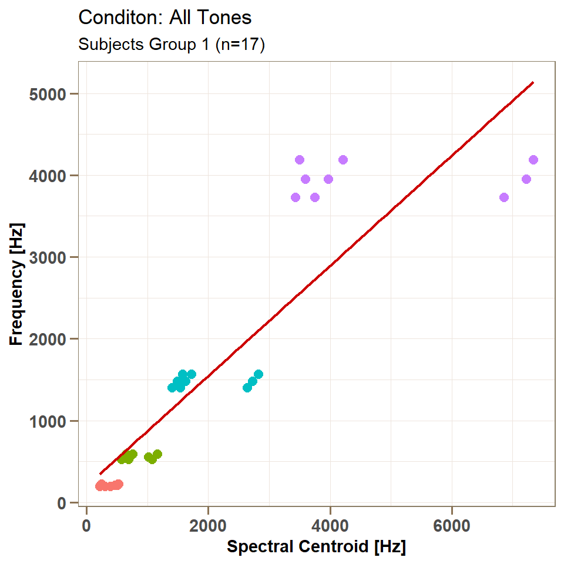

```r
plot.freq_centroid <-
  ggplot(data_group1, mapping = aes(y = frequency, x = centroid, colour=factor(frequency_bin)))+
  geom_point(size = 2.5)+
  geom_smooth(method = lm, colour="red3", se=FALSE, aes(group =1), linewidth = 0.75)+
  theme_light()+
  theme(legend.position="none",
        axis.ticks = element_line(color = "burlywood4", linewidth = 0.6),
        axis.ticks.length = unit(.18, "cm"),
        axis.text.x = element_text(size = 11, face = "bold"),
        axis.text.y = element_text(size= 11, face = "bold"),
        panel.background = element_rect(fill = "white"),
        panel.grid.major = element_line(color = "seashell2"),
        panel.grid.minor = element_line(color = "seashell2"),
        panel.border = element_rect(color = "wheat4"),
        axis.title = element_text(size= 11, color = "black", face = "bold"),
        strip.background = element_rect(fill= "lemonchiffon2"),
        strip.text = element_text(color = "burlywood4", face = "bold", size = 11))+
  xlab(label = "Spectral Centroid [Hz]")+
  ylab(label = "Frequency [Hz]")+
  ggtitle(label = "Conditon: All Tones", subtitle = "Subjects Group 1 (n=17)")

print(plot.freq_centroid)
```

Well, we can pretty much conclude from that, that higher f0 = higher spectral centroids.

#### Checking for interaction (Multicollinearity)

We can also check if interaction is a thing for these predictors by creating a lm without interaction and then check for multicollinaerity. So lets be extra af as always and do a multi-way ANCOVA without interaction and then check:

```r
#First, frequency_bin needs to be categorical:
data_group1$frequency_bin <- as.factor(data_group1$frequency_bin)

#Ancova without interaction:
ancova.ele_freq_acoustics <- lm(elevation_diff ~ frequency_bin + centroid + flatness + roll_off, data = data_group1)

#Some statistics first:
anova(ancova.ele_freq_acoustics)
```

```
## Analysis of Variance Table
##
## Response: elevation_diff
##                 Df  Sum Sq Mean Sq F value    Pr(>F)
## frequency_bin    3   83897 27965.8 78.0565 < 2.2e-16 ***
## centroid         1    3689  3689.0 10.2965  0.001337 **
## flatness         1     935   935.3  2.6106  0.106188
## roll_off         1     155   154.7  0.4319  0.511083
## Residuals     9174 3286828   358.3
## ---
## Signif. codes:  0 '***' 0.001 '**' 0.01 '*' 0.05 '.' 0.1 ' ' 1
```

The first statistics (all conditions) predict a correlation between our basic model variables (elevation_diff~frequency-bin), which confirms the presence of the Pratts Effect. For centroid we also get a significant effect. It seems to predict the Pratt’s Effect.

Now we check our standard assumptions:

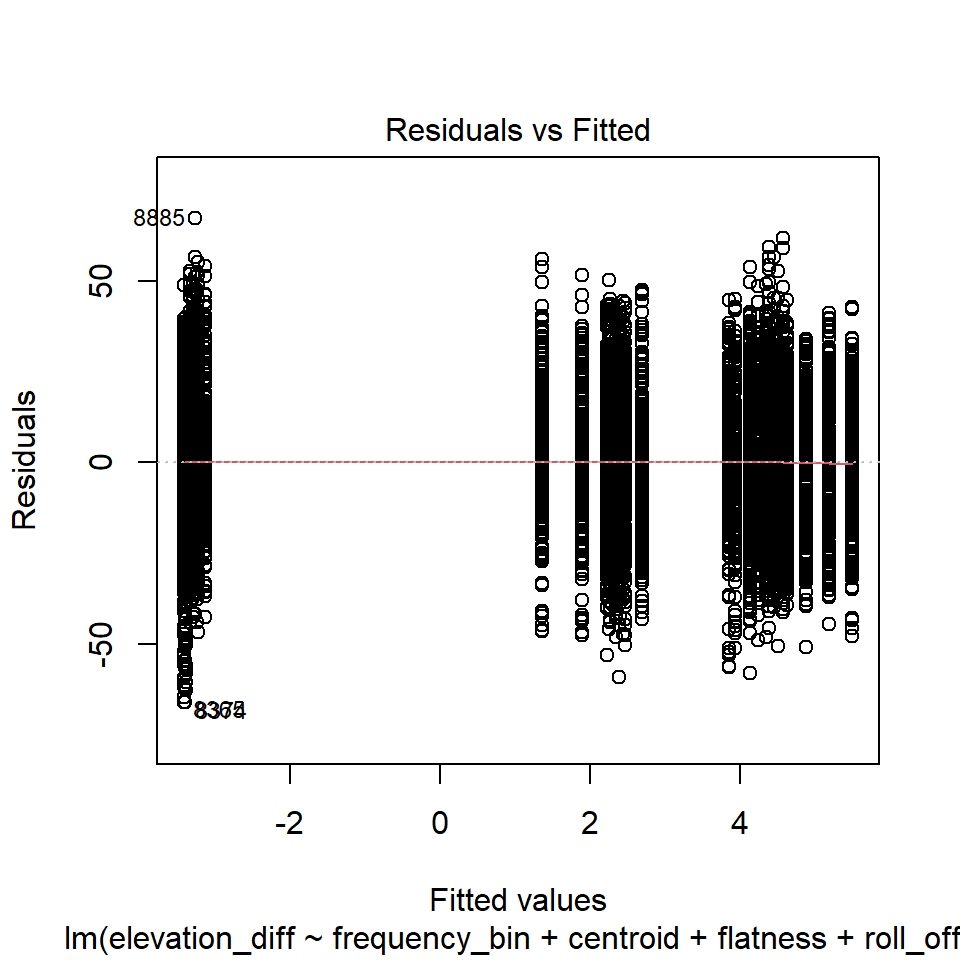

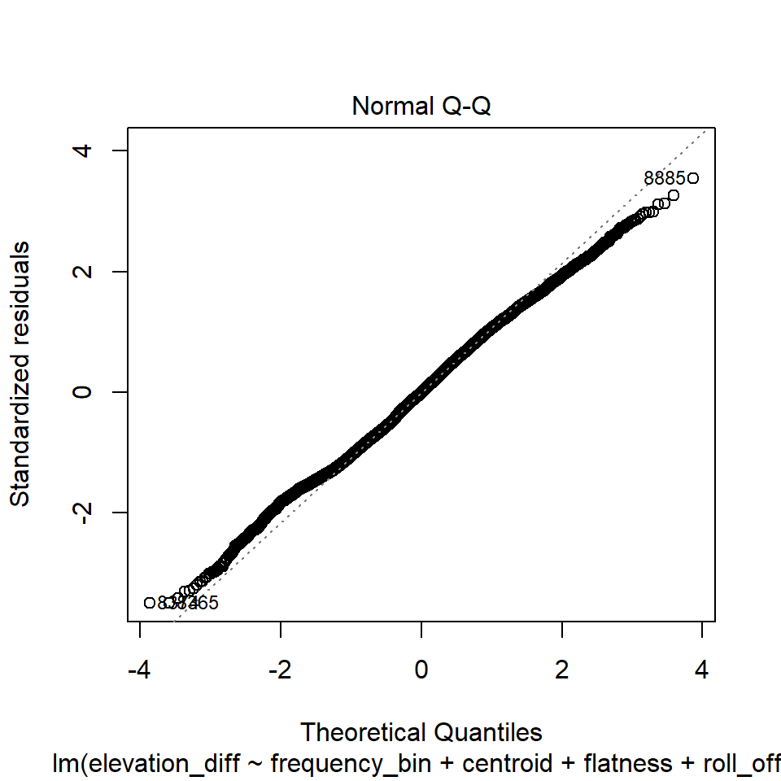

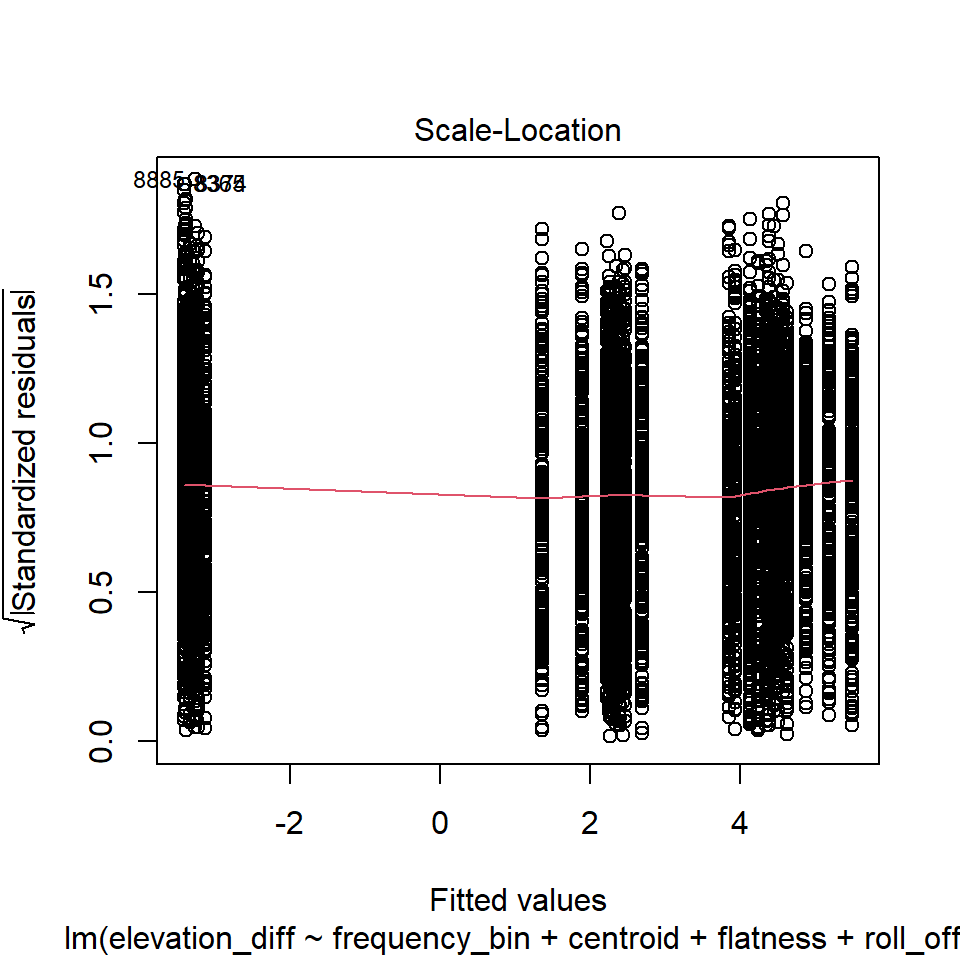

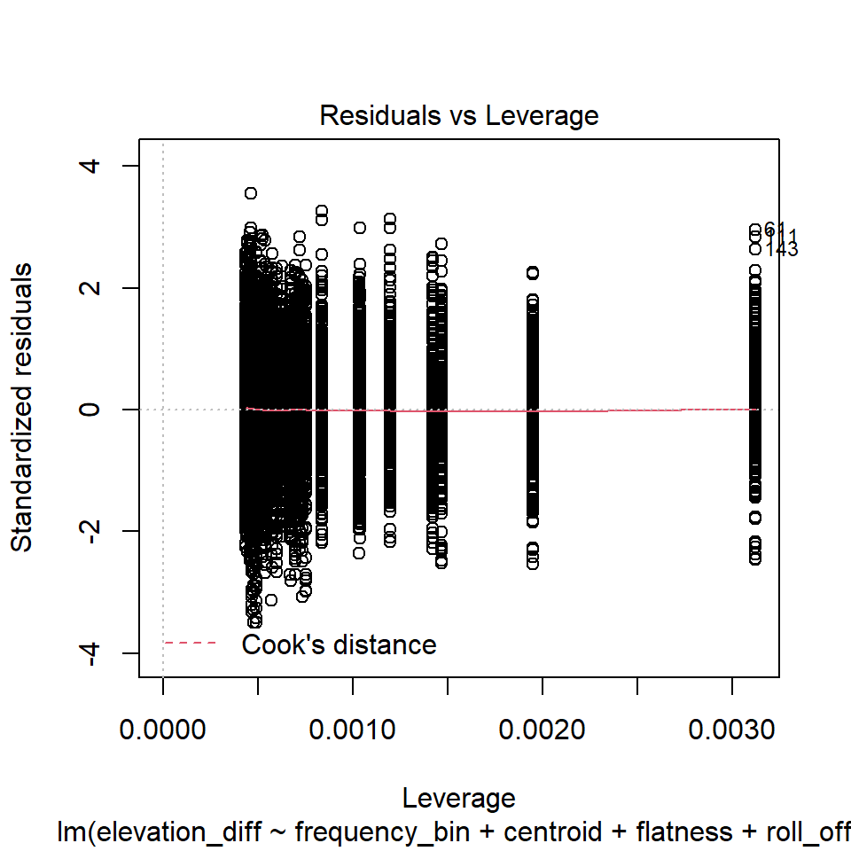

```r
#diagnostic plots (the terror begins):
plot(ancova.ele_freq_acoustics)
```

```r
#looks clustered (its grouped) but normally distributed and no influential outliers! So were good!
```

Last but not least, we need to check our new assumption for our multiple linear regression:

#### No multicollinearity

… this means that our x variables need to be independent of each other (no interaction).

The function vif() gives a number for each X variable. The number indicates the degree to which our X variables are redundant or explain the same variation in the model. A high number means that a variable doesn’t add much to the model that isn’t already explained by other variables (Interaction).

What do I do if I have a high VIF? The general rule for VIF is that as long as the number is <5 the amount of multicollinearity is negligible.

```r
#CHECKING FOR INTERACTION:
vif(ancova.ele_freq_acoustics)
```

```
##                    GVIF Df GVIF^(1/(2*Df))
## frequency_bin  80.52193  3        2.078033
## centroid      305.91700  1       17.490483
## flatness       22.83385  1        4.778477
## roll_off       76.34798  1        8.737733
```

```r
#all numbers are bigger than 5
#Our assumption is true: There is interaction. Periodt! Seems like we need to adjust the model and add interaction
```

For understanding the table: GVIF … generalized variance-inflation factors VIF … variance-inflation factors

Why not VIF but GVIF-values in table? If any terms in an unweighted linear model have more than 1 df (for us frequency_bin, df=3), then generalized variance-inflation factors are calculated. If we would check for a model where frequency_bin would be categorical but continous, we would get VIF values because then frequency_bin would have df=1.

The prove:

```r
data_group1$frequency_bin <- as.numeric(data_group1$frequency_bin)
#Lets test this:
model <- lm(elevation_diff~frequency+centroid+flatness+roll_off, data= data_group1)
vif(model)
```

```
## frequency  centroid  flatness  roll_off
##  62.88957 277.90117  16.16242  81.95946
```

```r
#all numbers would still be wayyy above 5 but this time its only VIF numbers.
```

At this point I’m pretty certain that we should consider for interaction.

#### Adding interaction to our ANCOVA:

We assume that the acoustic parameters of each stimulus interact with their f0-frequency.

```r
#need to set frequency_bin back to categorical before continuing:
data_group1$frequency_bin <- as.factor(data_group1$frequency_bin)

#Lets create a model considering for interaction:
ancova.ele_freqXacoustics <- lm(elevation_diff ~ frequency_bin * centroid * flatness * roll_off, data = data_group1)

#Now an ANOVA table, which is confusing bc ANCOVA it is, but the right way to do it:
anova(ancova.ele_freqXacoustics)
```

```
## Analysis of Variance Table
##
## Response: elevation_diff
##                                            Df  Sum Sq Mean Sq F value    Pr(>F)
## frequency_bin                               3   83897 27965.8 78.3167 < 2.2e-16
## centroid                                    1    3689  3689.0 10.3309  0.001313
## flatness                                    1     935   935.3  2.6193  0.105608
## roll_off                                    1     155   154.7  0.4333  0.510380
## frequency_bin:centroid                      3   12578  4192.5 11.7410 1.129e-07
## frequency_bin:flatness                      3     275    91.7  0.2569  0.856492
## centroid:flatness                           1       2     1.8  0.0050  0.943454
## frequency_bin:roll_off                      3     178    59.3  0.1660  0.919333
## centroid:roll_off                           1     768   767.8  2.1501  0.142595
## flatness:roll_off                           1     644   644.4  1.8045  0.179204
## frequency_bin:centroid:flatness             3    2082   693.9  1.9431  0.120296
## frequency_bin:centroid:roll_off             3    1058   352.8  0.9879  0.397300
## frequency_bin:flatness:roll_off             3     797   265.7  0.7439  0.525737
## centroid:flatness:roll_off                  1      11    11.2  0.0313  0.859552
## frequency_bin:centroid:flatness:roll_off    3    1453   484.5  1.3567  0.254061
## Residuals                                9149 3266982   357.1
##
## frequency_bin                            ***
## centroid                                 **
## flatness
## roll_off
## frequency_bin:centroid                   ***
## frequency_bin:flatness
## centroid:flatness
## frequency_bin:roll_off
## centroid:roll_off
## flatness:roll_off
## frequency_bin:centroid:flatness
## frequency_bin:centroid:roll_off
## frequency_bin:flatness:roll_off
## centroid:flatness:roll_off
## frequency_bin:centroid:flatness:roll_off
## Residuals
## ---
## Signif. codes:  0 '***' 0.001 '**' 0.01 '*' 0.05 '.' 0.1 ' ' 1
```

Lets interpret those results:

ANOVA-table We use this to see if our acoustic parameters influence elevation_diff alone and then the relationship between elevation_diff and frequency_bin (the Pratt’s effect)

#### Influence acoustic parameters on elevation_diff:

row 1 (frequency_bin) … frequency_bin has effect on elevation_diff (p< 2.2e-16 ***) row 2 (centroid) … centroid has effect on elevation_diff (p= 0.001313** ) row 3 (flatness) … flatness has no effect on elevation_diff (p= 0.105608) row 4 (roll_off) … roll_off has no effect on elevation_diff (p= 0.510380)

#### Interaction acoustic parameters and elevation_diff~frequency_bin:

row 5 (frequency_bin:centroid) … interaction between frequency_bin and centroid (p= 1.129e-07 ***) row 6 (frequency_bin:flatness) … no interaction between frequency_bin and flatness (p= 0.856492) row 8 (frequency_bin:roll_off) … no interaction between frequency_bin and roll-off (p= 0.919333)

Seems like centroid of a stimulus predicts the Pratts-Effect, but how? We have to do the Post-Hoc Thingy again:

I’m a little confused, because we (Me + my 16 personalities) can’t test our model as a whole. The emmrends() thing used for Ancova will only show output for 1 interaction of our original model each time (we can only test the acoustic parameters as predictors separately). But since were still using our original model to do so, I think the results should still tell us a little more about the statistics:

Since centroid was the only acoustic parameter that interacts with the Pratt’s Effect in general (all conditions) we will test it to see how:

```r
emtrends(ancova.ele_freqXacoustics,
         pairwise~frequency_bin, #our categorical predictor variable
         var="centroid") #one of our continuous predictor variable from the original model
```

```
## NOTE: Results may be misleading due to involvement in interactions
```

```
## $emtrends
##  frequency_bin centroid.trend     SE   df lower.CL upper.CL
##  1                     8.0604 4.6600 9149  -1.0749   17.196
##  2                     0.0582 0.1620 9149  -0.2590    0.375
##  3                     0.6273 1.9100 9149  -3.1185    4.373
##  4                     0.0103 0.0531 9149  -0.0938    0.114
##
## Confidence level used: 0.95
##
## $contrasts
##  contrast                        estimate   SE   df t.ratio p.value
##  frequency_bin1 - frequency_bin2   8.0022 4.66 9149   1.716  0.3153
##  frequency_bin1 - frequency_bin3   7.4331 5.04 9149   1.476  0.4523
##  frequency_bin1 - frequency_bin4   8.0500 4.66 9149   1.727  0.3095
##  frequency_bin2 - frequency_bin3  -0.5691 1.92 9149  -0.297  0.9909
##  frequency_bin2 - frequency_bin4   0.0479 0.17 9149   0.281  0.9923
##  frequency_bin3 - frequency_bin4   0.6170 1.91 9149   0.323  0.9884
##
## P value adjustment: tukey method for comparing a family of 4 estimates
```

```r
#this shows the error "NOTE: Results may be misleading due to involvement in interactions"
```

emtrends table … shows you the individual slopes of the lines in each of the categories of our categorical predictor variable. It has 6 columns:

frequency_bin … categorical predictor variable

centroid.trend … slope of relationship between response variable (elevation_diff) and continuous predictor variable (centroid) for each category in our categorical predictor variable (frequency_bin 1 till 4)

SE … standard error around the slope

df … residual degrees of freedom

lower.CL … lower 95% confidence level

upper.CL … upper 95% confidence level

#### Results

This model with interaction showed us that the Pratts Effect is first of all a thing in our data, because we found that frequency_bin predicts elevation_diff in our first Anova-statistics-table (p=< 2.2e-16 ***). We also found out, that centroid predicts elevation_diff (p=0.001313** ). Lastly, we saw that frequency_bin and centroid interact with eachother, as my little plot in the very beginning predicted (maybe it was not so overkill to do it). These results make a lot of sense to me so far! For the further statistics: Since all of the slopes in our emmtrends-table are positive i think higher centroids seem to predict a higher elevation differences in each frequency_bin. Interesting! For the first frequency_bin (f0= 208 Hz) the slope is the steepest (centroid.trend = 8.0604).

Lastly, lets plot interaction to make the results visual:

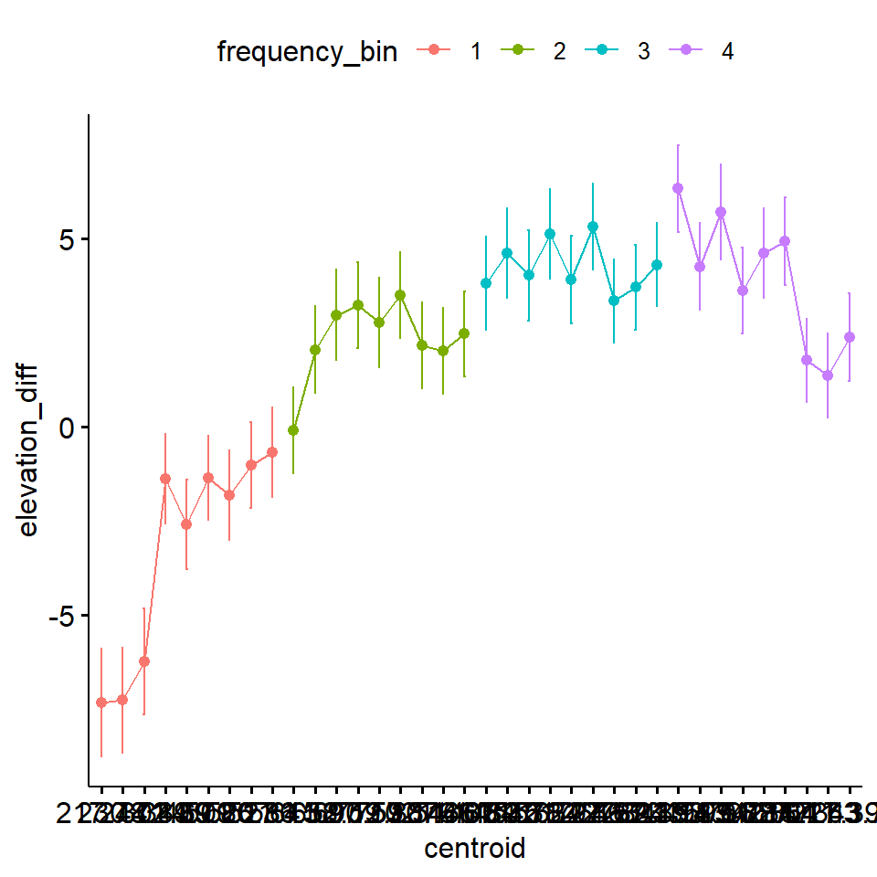

```r
#Plot for centroid:
interaction.plot_centroid <-
  ggline(data_group1, x = "centroid", y = "elevation_diff", color = "frequency_bin",
       add = c("mean_se"))

interaction.plot_centroid
```

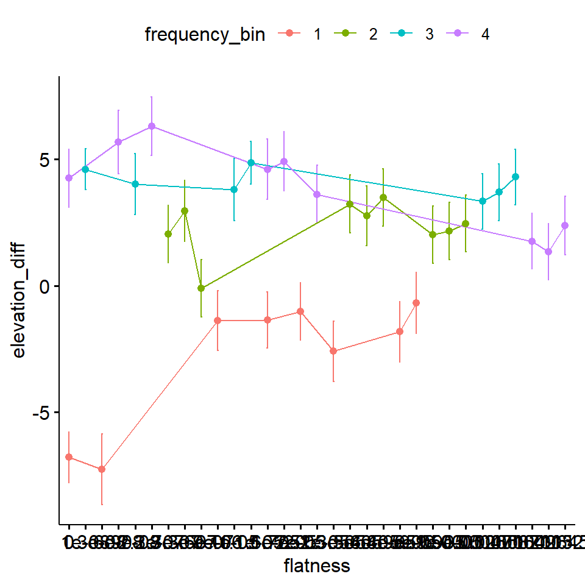

```r
#Plot for flatness:
interaction.plot_flatness <-
  ggline(data_group1, x = "flatness", y = "elevation_diff", color = "frequency_bin",
       add = c("mean_se"))

interaction.plot_flatness
```

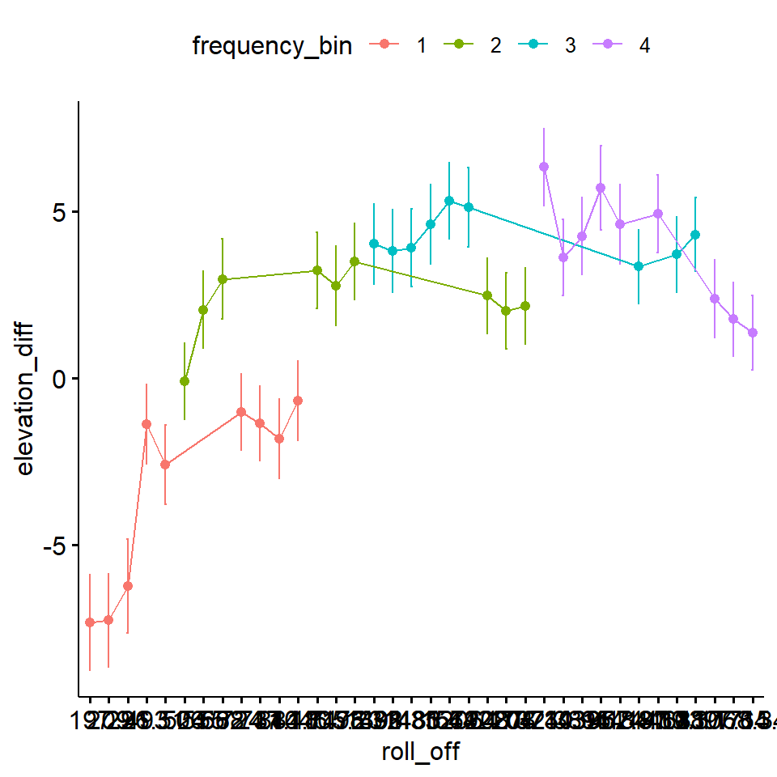

```r
#Plot for roll-off:
interaction.plot_rolloff <-
  ggline(data_group1, x = "roll_off", y = "elevation_diff", color = "frequency_bin",
       add = c("mean_se"))

interaction.plot_rolloff
```

I think this kinda confirms why we only have centroid as a significant predictor for our effect from the acoustic parameters.

### Seperate interaction-model acoustic parameters?:

I was wondering whether models that account for seperating the acoustic parameters as interacting predictors would make sense. I also wanna see how much the results differ from our all-in-one model before.

Lets start with centroid because it seems to have the largest influence as an acoustic parameter:

## Centroid

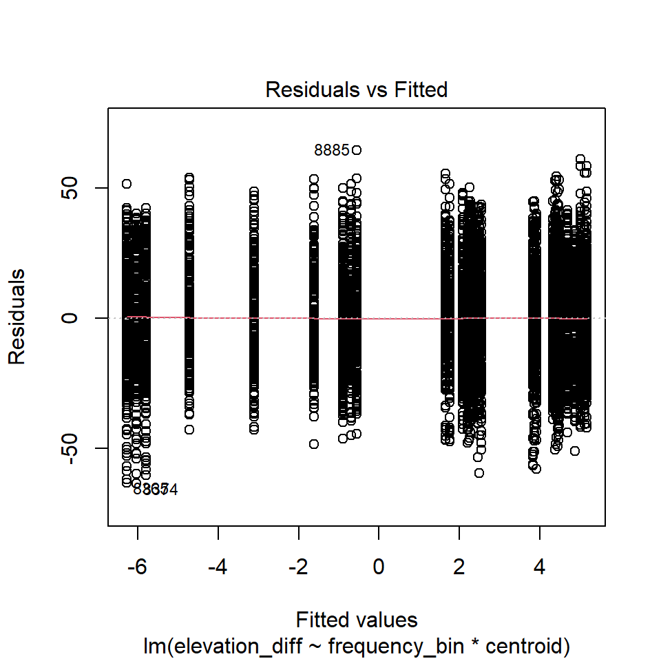

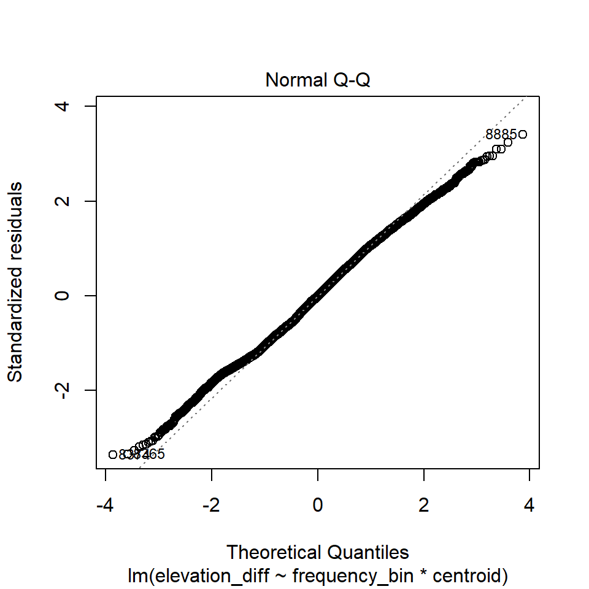

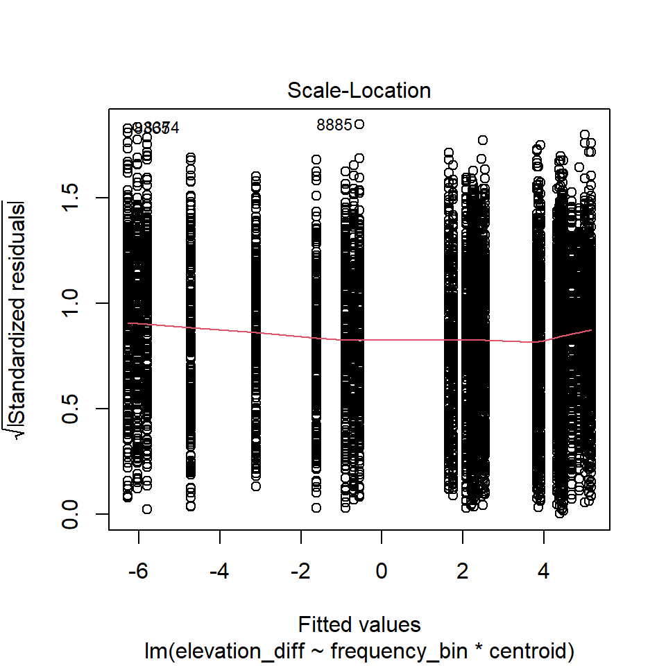

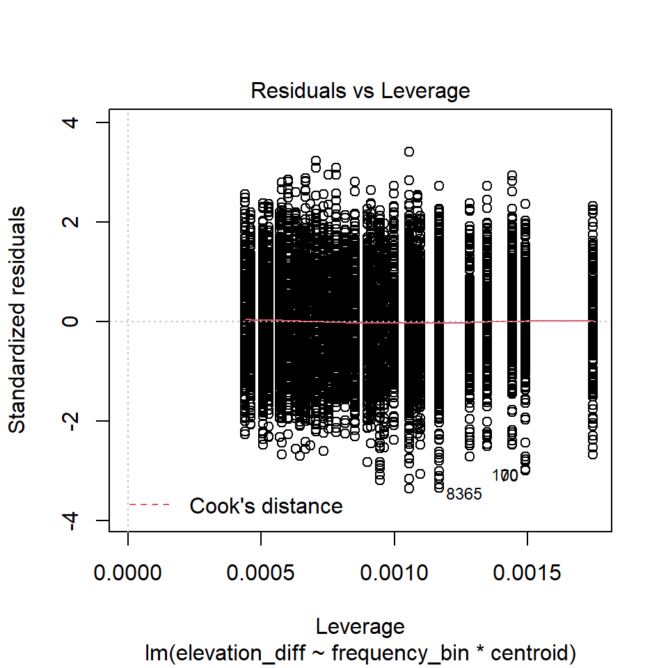

```r
#only making sure were on the safe side:
data_group1$frequency_bin <- as.factor(data_group1$frequency_bin)

#the model, with interaction because i think we can fairly agree on that one after our first results:
ancova.ele_freqXcentroid <- lm(elevation_diff~frequency_bin *centroid, data = data_group1)

#diagnostic plots:
plot(ancova.ele_freqXcentroid)
```

```r
#sweet stuff! Lets continue...
```

```r
#first statistics:
anova(ancova.ele_freqXcentroid)
```

```
## Analysis of Variance Table
##
## Response: elevation_diff
##                          Df  Sum Sq Mean Sq F value    Pr(>F)
## frequency_bin             3   83897   27966  78.344 < 2.2e-16 ***
## centroid                  1    3689    3689  10.335   0.00131 **
## frequency_bin:centroid    3   13515    4505  12.620 3.138e-08 ***
## Residuals              9173 3274403     357
## ---
## Signif. codes:  0 '***' 0.001 '**' 0.01 '*' 0.05 '.' 0.1 ' ' 1
```

```r
#Interesting...
```

Interpreting that: First of all, we get the same results like we did with our all-in-one model: Frequency_bin predicts elevation_diff (p< 2.2e-16 **) and centroid does so too (p=0.00131** ). the p-values are identical compared to the all-in-one model. BUT! When it comes to the p-values of the interaction between frequency_bin and centroid we get a slight difference. Thise time, its more significant (p=3.138e-08 **). The results still tell the same story our results told from the all-in-one model with the last little difference. Kinda sus, lets continue to see whether there are more differences.

We need the Post-Hoc for more in-depth stats:

```r
emtrends(ancova.ele_freqXcentroid,
         pairwise~frequency_bin, #our categorical predictor variable
         var="centroid") #our continuous predictor variable
```

```
## $emtrends
##  frequency_bin centroid.trend       SE   df lower.CL  upper.CL
##  1                   0.018489 0.003170 9173  0.01227  0.024704
##  2                   0.000600 0.001910 9173 -0.00314  0.004342
##  3                  -0.000459 0.000705 9173 -0.00184  0.000923
##  4                  -0.000899 0.000243 9173 -0.00138 -0.000422
##
## Confidence level used: 0.95
##
## $contrasts
##  contrast                        estimate       SE   df t.ratio p.value
##  frequency_bin1 - frequency_bin2 0.017889 0.003700 9173   4.834  <.0001
##  frequency_bin1 - frequency_bin3 0.018948 0.003250 9173   5.834  <.0001
##  frequency_bin1 - frequency_bin4 0.019388 0.003180 9173   6.097  <.0001
##  frequency_bin2 - frequency_bin3 0.001059 0.002040 9173   0.521  0.9542
##  frequency_bin2 - frequency_bin4 0.001499 0.001920 9173   0.779  0.8641
##  frequency_bin3 - frequency_bin4 0.000439 0.000746 9173   0.589  0.9354
##
## P value adjustment: tukey method for comparing a family of 4 estimates
```

Lets plot again:

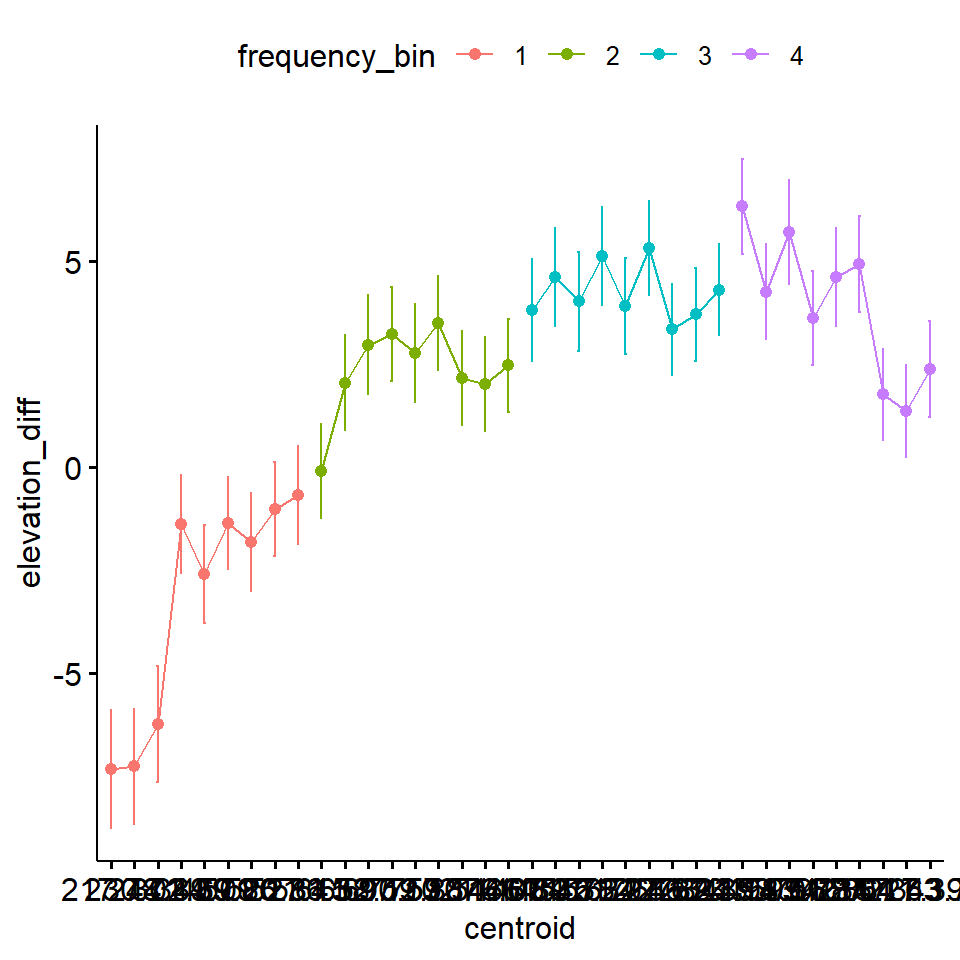

```r
interaction.plot_centroid
```

Okay-dokey… I think the results do make sense. So, valid question: Which model is the more correct/better one? (Zofia, I need your professional opion on that i think)

*My Suggestion: I think we should account for each acoustic parameter individually and not use the results of the all-in-one model* This would mean that i should create two more models to check for the influence of the other two acoustic parameters. Lets do that then:

## Flatness

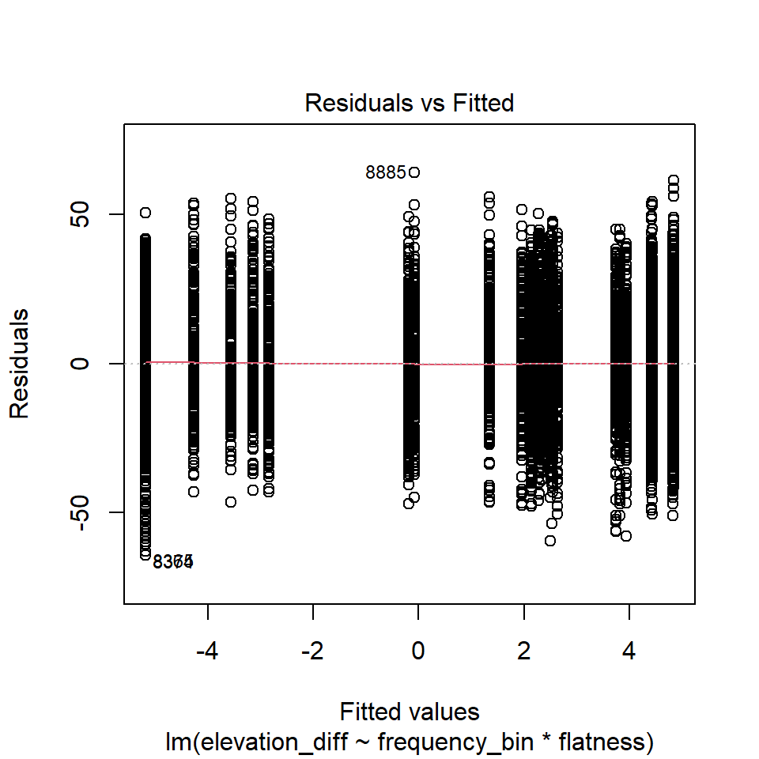

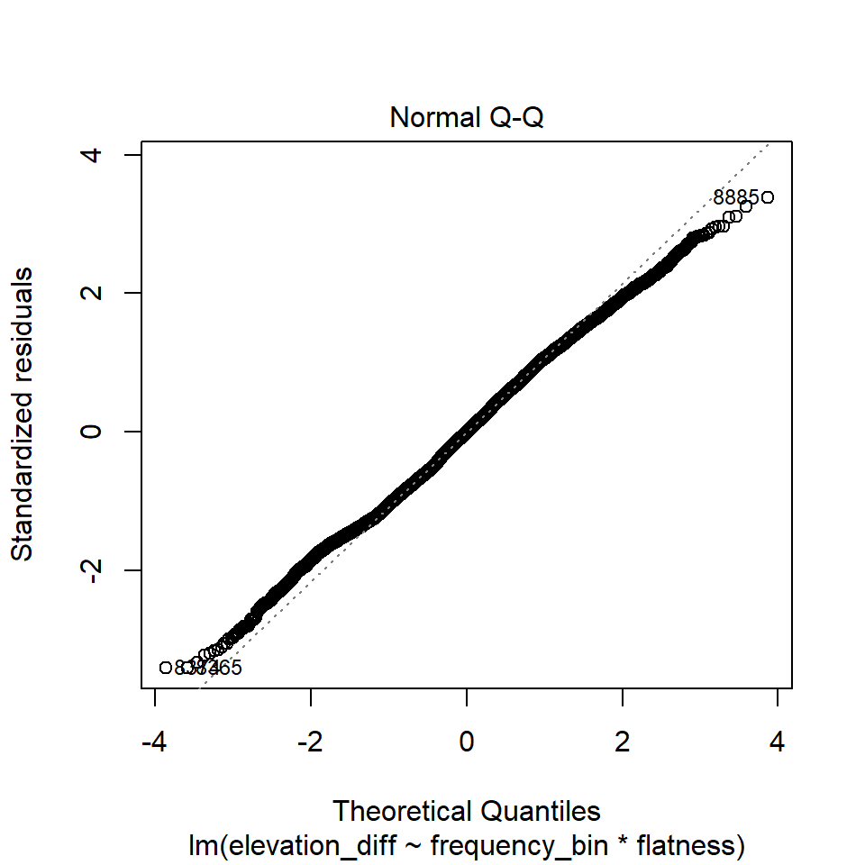

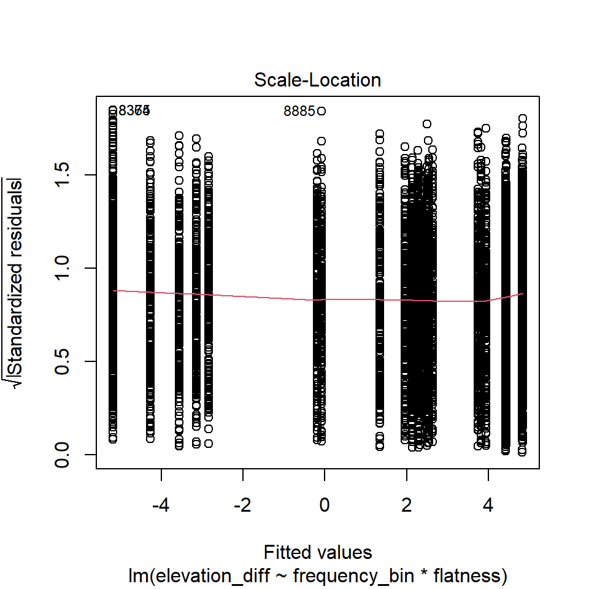

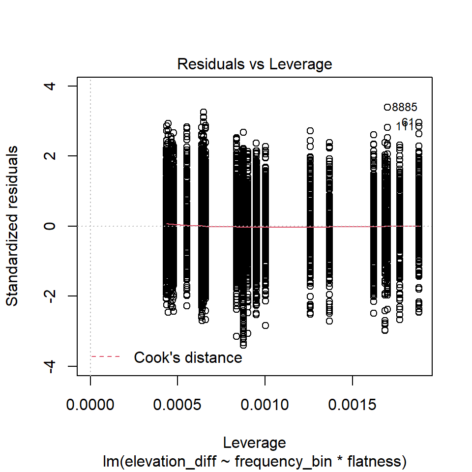

```r
#the model with interaction again:
ancova.ele_freqXflatness<- lm(elevation_diff~frequency_bin *flatness, data = data_group1)

#diagnostic plots:
plot(ancova.ele_freqXflatness)
```

```r
#Luck is on my side again (actually i think they don't even change but I'm not professional enough to tell). Lets continue!
```

```r
#first statistics:
anova(ancova.ele_freqXflatness)
```

```
## Analysis of Variance Table
##
## Response: elevation_diff
##                          Df  Sum Sq Mean Sq F value    Pr(>F)
## frequency_bin             3   83897 27965.8 78.2407 < 2.2e-16 ***
## flatness                  1    4410  4410.3 12.3389 0.0004458 ***
## frequency_bin:flatness    3    8462  2820.7  7.8915 2.962e-05 ***
## Residuals              9173 3278734   357.4
## ---
## Signif. codes:  0 '***' 0.001 '**' 0.01 '*' 0.05 '.' 0.1 ' ' 1
```

```r
#Whaaaaaaaat???!!
```

Okay… well it seems like we have some major differences in comparison to our all-in-one model again: We get the same results like we did with our all-in-one model and centroid-model before: Frequency_bin predicts elevation_diff (p< 2.2e-16 *). Now here comes the differences: For this model, flatness predicts elevation_diff too (p=0.0004458* ).And when it comes to the interaction between frequency_bin and flatness we can also so a difference, because now there is an interaction between frequency_bin and flatness. But does that make sense?

Lets plot again:

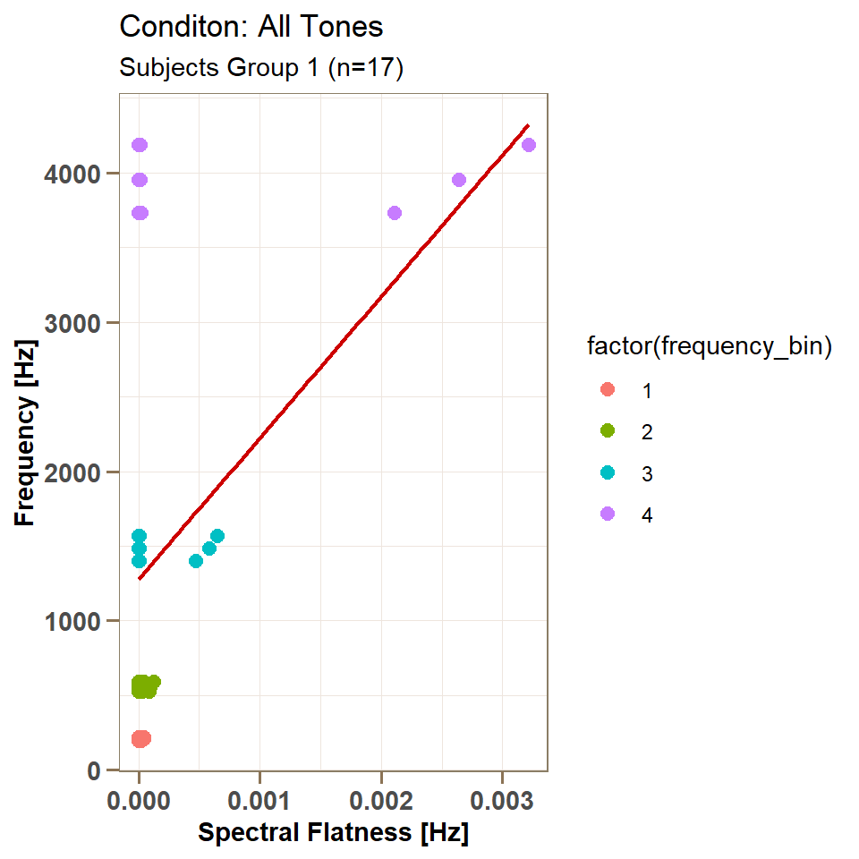

```r
plot.freq_flatness <-
  ggplot(data_group1, mapping = aes(y = frequency, x = flatness, colour=factor(frequency_bin)))+
  geom_point(size = 2.5)+
  geom_smooth(method = lm, colour="red3", se=FALSE, aes(group =1), linewidth = 0.75)+
  theme_light()+
  theme(legend.position="right",
        axis.ticks = element_line(color = "burlywood4", linewidth = 0.6),
        axis.ticks.length = unit(.18, "cm"),
        axis.text.x = element_text(size = 11, face = "bold"),
        axis.text.y = element_text(size= 11, face = "bold"),
        panel.background = element_rect(fill = "white"),
        panel.grid.major = element_line(color = "seashell2"),
        panel.grid.minor = element_line(color = "seashell2"),
        panel.border = element_rect(color = "wheat4"),
        axis.title = element_text(size= 11, color = "black", face = "bold"),
        strip.background = element_rect(fill= "lemonchiffon2"),
        strip.text = element_text(color = "burlywood4", face = "bold", size = 11))+
  xlab(label = "Spectral Flatness [Hz]")+
  ylab(label = "Frequency [Hz]")+
  ggtitle(label = "Conditon: All Tones", subtitle = "Subjects Group 1 (n=17)")

print(plot.freq_flatness)
```

Well… i don’t know… Looks not like frequency and flatness have that much of a relation, they’re more like far cousins. We can kinda see that higher frequencies seem to be associated with higher flatness though.

Lets do some more statistics:

```r
emtrends(ancova.ele_freqXflatness,
         pairwise~frequency_bin, #our categorical predictor variable
         var="flatness") #our continuous predictor variable
```

```
## $emtrends
##  frequency_bin flatness.trend    SE   df lower.CL upper.CL
##  1                     102226 21400 9173    60321   144131
##  2                       3988  8910 9173   -13473    21448
##  3                      -1043  1470 9173    -3917     1831
##  4                      -1091   309 9173    -1698     -485
##
## Confidence level used: 0.95
##
## $contrasts
##  contrast                        estimate    SE   df t.ratio p.value
##  frequency_bin1 - frequency_bin2  98238.7 23200 9173   4.242  0.0001
##  frequency_bin1 - frequency_bin3 103269.2 21400 9173   4.819  <.0001
##  frequency_bin1 - frequency_bin4 103317.5 21400 9173   4.832  <.0001
##  frequency_bin2 - frequency_bin3   5030.5  9030 9173   0.557  0.9446
##  frequency_bin2 - frequency_bin4   5078.8  8910 9173   0.570  0.9411
##  frequency_bin3 - frequency_bin4     48.3  1500 9173   0.032  1.0000
##
## P value adjustment: tukey method for comparing a family of 4 estimates
```

Emtrends-table Looking at the column “flatness.trend” (again: shows the slope of the relationship between elevation_diff and our continuous predictor variable flatness for each category in our categorical predictor (frequency_bin):

These results are slowly convincing me that the best way to have a look at the influence of our acoustic parameters on the Pratts Effect is by creating a model for each condition. I’m going to continue with that.

### b) “Does the strength of the influence of the acoustic parameters on the correlation differ for each condition?”

### Harmonicomplex-Tones

I’ll try around here, so were gonna create a bunch of models. I’ll always start with a model for each condition containing all acoustic parameters at once and then some models that will account for them separatly.

### 1. All-in-One Model (Complex)

```r
#First, frequency_bin needs to be categorical:
data_group1_complex$frequency_bin <- as.factor(data_group1_complex$frequency_bin)

#Ancova without interaction:
ancova.complex.ele_freq_acoustics <- lm(elevation_diff ~ frequency_bin + centroid + flatness + roll_off, data = data_group1_complex)

#CHECKING FOR INTERACTION:
vif(ancova.complex.ele_freq_acoustics)
```

```
##                       GVIF Df GVIF^(1/(2*Df))
## frequency_bin 6.238869e+05  3        9.243809
## centroid      1.937014e+04  1      139.176637
## flatness      9.244354e+00  1        3.040453
## roll_off      1.970690e+04  1      140.381253
```

```r
#interesting...
```

So how do I continue? (a good question to ask yourself sometimes…)

I’d suggest to do it right way (as the statistic gods would want me to) and create two separate models for the all-in-one stuff: - One accounting for flatness’s interaction situation (Elevation_diff_complex ~ freq_bin_complex * flatness_complex), *see 1.2* - and one that will contain centroid and roll-off without interaction terms (Elevation_diff_complex ~ freq_bin_complex + centroid_complex + roll-off_complex )

“Okaaayyyy lets gooh!”

I’ll have a look at our no-interaction model for the complex tones first:

```r
#I'll just redefine the model from earlierand leave out flatness to make it less confusing:
ancova.complex.ele_freq_acoustics <- lm(elevation_diff ~ frequency_bin + centroid + roll_off, data = data_group1_complex)
```

Lets look at some diagnostic plots:

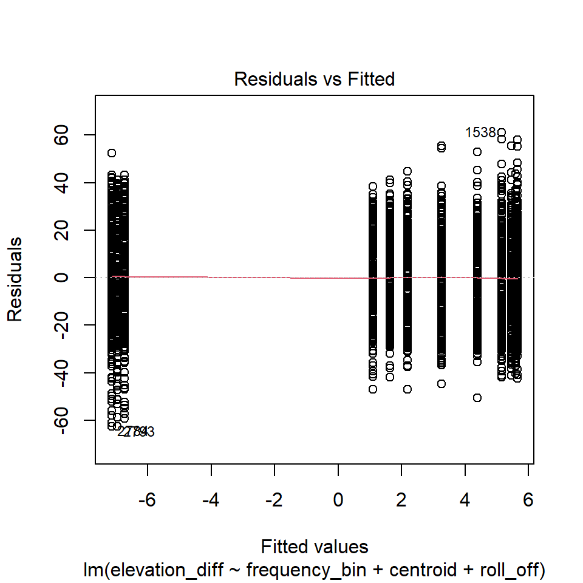

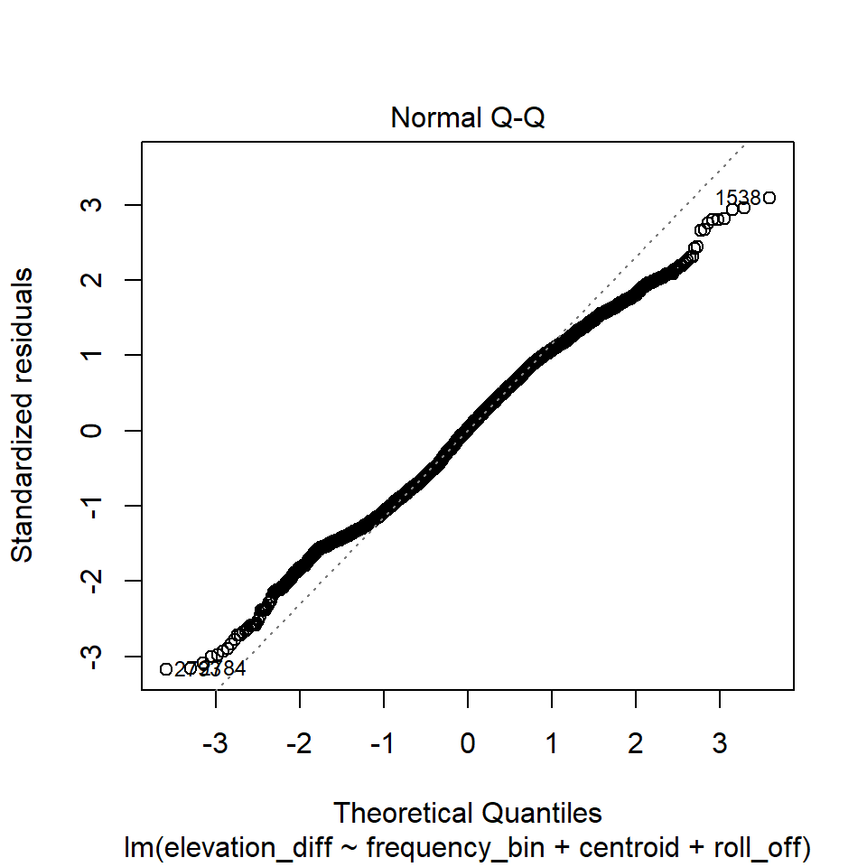

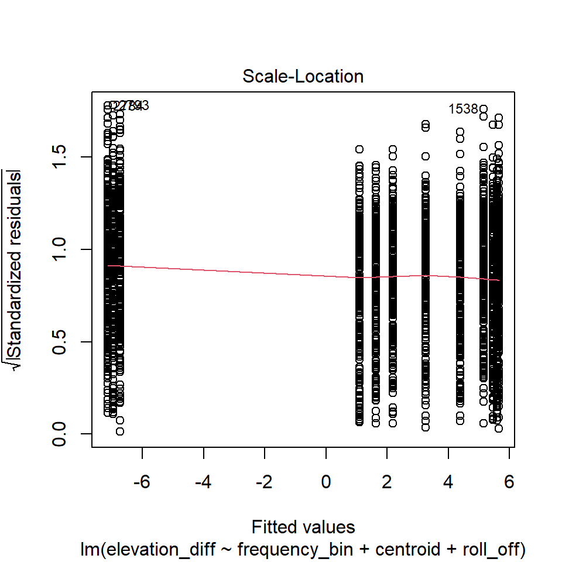

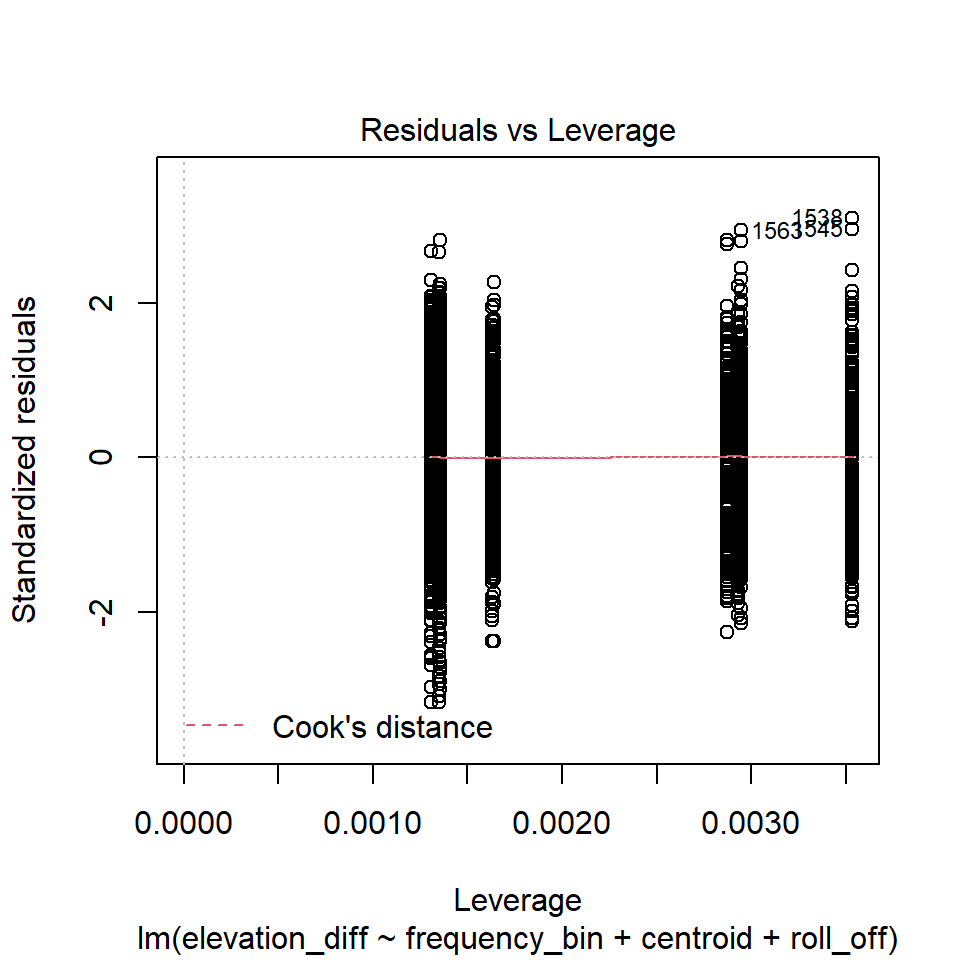

```r
#as always:
plot(ancova.complex.ele_freq_acoustics)
```

```r
#seems okay
```

Aaaand some statistics:

```r
#First the basic Anova stuff:
anova(ancova.complex.ele_freq_acoustics)
```

```
## Analysis of Variance Table
##
## Response: elevation_diff
##                 Df  Sum Sq Mean Sq F value Pr(>F)
## frequency_bin    3   72446 24148.6 61.8649 <2e-16 ***
## centroid         1     346   346.4  0.8874 0.3462
## roll_off         1     544   543.5  1.3924 0.2381
## Residuals     3054 1192108   390.3
## ---
## Signif. codes:  0 '***' 0.001 '**' 0.01 '*' 0.05 '.' 0.1 ' ' 1
```

```r
#Now our Post-Hoc thingy, but twice:
emmeans(ancova.complex.ele_freq_acoustics,
         pairwise~frequency_bin, var="centroid")
```

```
## $emmeans
##  frequency_bin emmean    SE   df lower.CL upper.CL
##  208             5.30  9.35 3054   -13.04    23.64
##  554             8.04  6.10 3054    -3.91    19.99
##  1480           -4.09  6.57 3054   -16.96     8.79
##  3951           -4.74 14.00 3054   -32.13    22.66
##
## Confidence level used: 0.95
##
## $contrasts
##  contrast                              estimate    SE   df t.ratio p.value
##  frequency_bin208 - frequency_bin554     -2.744  4.01 3054  -0.685  0.9029
##  frequency_bin208 - frequency_bin1480     9.386 13.80 3054   0.678  0.9054
##  frequency_bin208 - frequency_bin3951    10.034 22.50 3054   0.447  0.9702
##  frequency_bin554 - frequency_bin1480    12.131  9.97 3054   1.216  0.6166
##  frequency_bin554 - frequency_bin3951    12.778 19.90 3054   0.643  0.9180
##  frequency_bin1480 - frequency_bin3951    0.648 15.60 3054   0.042  1.0000
##
## P value adjustment: tukey method for comparing a family of 4 estimates
```

```r
#we also need it for roll-offf:
emtrends(ancova.complex.ele_freq_acoustics,
         pairwise~frequency_bin, var="roll_off")
```

```
## $emtrends
##  frequency_bin roll_off.trend     SE   df lower.CL upper.CL
##  208                  -0.0404 0.0342 3054   -0.108   0.0267
##  554                  -0.0404 0.0342 3054   -0.108   0.0267
##  1480                 -0.0404 0.0342 3054   -0.108   0.0267
##  3951                 -0.0404 0.0342 3054   -0.108   0.0267
##
## Confidence level used: 0.95
##
## $contrasts
##  contrast                              estimate SE   df t.ratio p.value
##  frequency_bin208 - frequency_bin554          0  0 3054     NaN     NaN
##  frequency_bin208 - frequency_bin1480         0  0 3054     NaN     NaN
##  frequency_bin208 - frequency_bin3951         0  0 3054     NaN     NaN
##  frequency_bin554 - frequency_bin1480         0  0 3054     NaN     NaN
##  frequency_bin554 - frequency_bin3951         0  0 3054     NaN     NaN
##  frequency_bin1480 - frequency_bin3951        0  0 3054     NaN     NaN
##
## P value adjustment: tukey method for comparing a family of 2 estimates
```

```r
#lets have a look
```

### 1.1 Spectral Centroid (Complex):

```r
#Were working with the complex-tones first:
data_group1_complex$frequency_bin <- as.factor(data_group1_complex$frequency_bin)

ancova_complex_ele_freqXcentroid <- lm(elevation_diff~frequency_bin*centroid, data=data_group1_complex)
```

At this point maybe to be very sure that interaction between acoustic parameters and the frequencies of our condition is given, we could (or should?) test for multicollinearity again:

```r
#etting frequency_bin as categorical again:
data_group1_complex$frequency_bin <- as.factor(data_group1_complex$frequency_bin)

#lets create the model without interaction to check for MULTICOLLINEARITY:
ancova_complex_ele_freq_centroid <- lm(elevation_diff~frequency_bin+centroid, data=data_group1_complex)

vif(ancova_complex_ele_freq_centroid)
```

```
##                   GVIF Df GVIF^(1/(2*Df))
## frequency_bin 591.0546  3         2.89693
## centroid      591.0546  1        24.31162
```

```r
#were good, interaction is definitely a thing for centroid
```

Lets continue our analysis with the interaction model then:

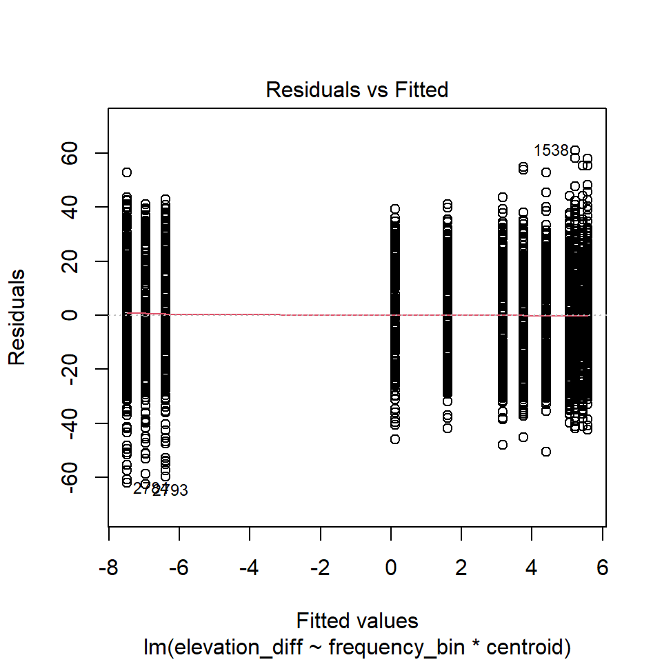

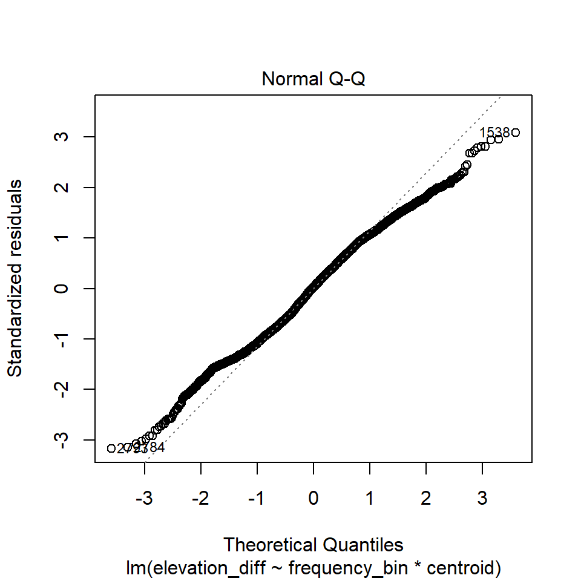

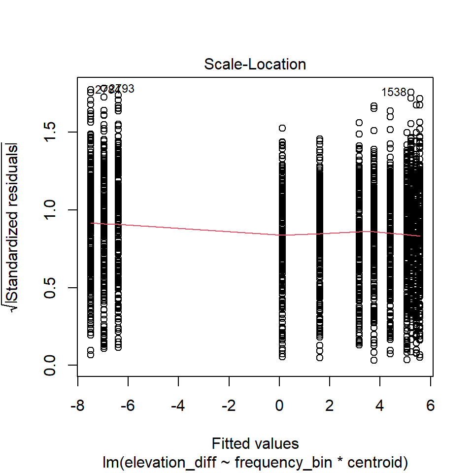

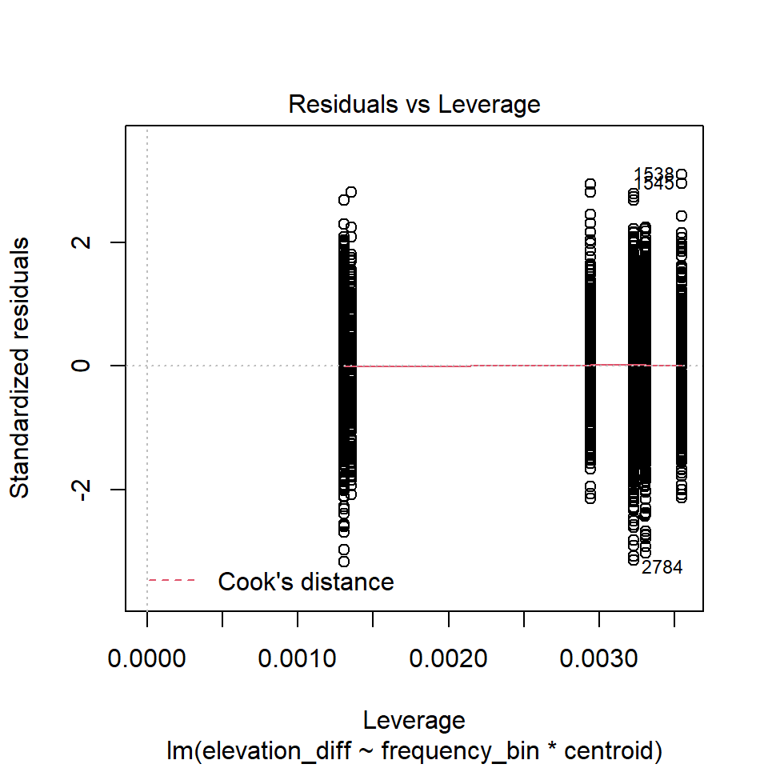

```r
#diagnostic plots-time:
plot(ancova_complex_ele_freqXcentroid)
```

```r
#looks okay, kinda normally distributed, but it still count to me
```

More Stats:

```r
#ANOVA:
anova(ancova_complex_ele_freqXcentroid)
```

```
## Analysis of Variance Table
##
## Response: elevation_diff
##                          Df  Sum Sq Mean Sq F value Pr(>F)
## frequency_bin             3   72446 24148.6 61.8599 <2e-16 ***
## centroid                  1     346   346.4  0.8874 0.3463
## frequency_bin:centroid    3    1228   409.2  1.0482 0.3700
## Residuals              3052 1191424   390.4
## ---
## Signif. codes:  0 '***' 0.001 '**' 0.01 '*' 0.05 '.' 0.1 ' ' 1
```

```r
#Post-Hoc:
emtrends(ancova_complex_ele_freqXcentroid,
         pairwise~frequency_bin, var="centroid")
```

```
## $emtrends
##  frequency_bin centroid.trend      SE   df lower.CL upper.CL
##  208                  0.04124 0.06560 3052 -0.08743   0.1699
##  554                  0.04283 0.02460 3052 -0.00534   0.0910
##  1480                 0.00728 0.00975 3052 -0.01184   0.0264
##  3951                -0.00213 0.01050 3052 -0.02277   0.0185
##
## Confidence level used: 0.95
##
## $contrasts
##  contrast                              estimate     SE   df t.ratio p.value
##  frequency_bin208 - frequency_bin554   -0.00159 0.0701 3052  -0.023  1.0000
##  frequency_bin208 - frequency_bin1480   0.03397 0.0663 3052   0.512  0.9563
##  frequency_bin208 - frequency_bin3951   0.04337 0.0665 3052   0.653  0.9147
##  frequency_bin554 - frequency_bin1480   0.03556 0.0264 3052   1.345  0.5342
##  frequency_bin554 - frequency_bin3951   0.04496 0.0267 3052   1.682  0.3334
##  frequency_bin1480 - frequency_bin3951  0.00940 0.0143 3052   0.655  0.9137
##
## P value adjustment: tukey method for comparing a family of 4 estimates
```

#### Results

Anova-table: First statistics tell us, that the Pratts Effect is generally given (p<2e-16 ***) and that centroid does not predict differences in elevation (p=0.3463), neither interacts with frequency_bin (p=0.3700).

emtrends and emmeans-tables: The Post-Hoc results indicate, that if centroid were to predict elevation differences within each frequency_bin, there would be a positive relation (higher centroids result in higher elevation differences) for all frequency bins but the highest (3951 Hz). Here, the slope was negative. However, we have no significance for any of those, so we can conclude: For Harmoniccomplex-tones, the spectral centroid does not influence the presence and strength of the Pratts Effect.

Proving that with the Interaction-plot:

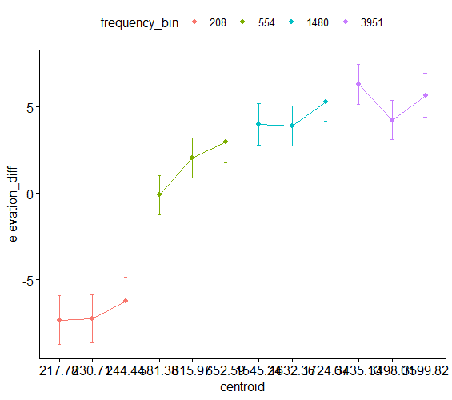

Interaction Plot

```r
#for visual presentation:
interaction.plot_complex_centroid <-
  ggline(data_group1_complex, x = "centroid", y = "elevation_diff", color = "frequency_bin",
       add = c("mean_se"))
```

This one makes really clear that within each frequency bin, centroid may predict elevation differences (as our positive slopes indicated) but not in the whole thing.

### 1.2 Spectral Flatness (Complex):

```r
#just to make sure:
data_group1_complex$frequency_bin <- as.factor(data_group1_complex$frequency_bin)

#Lets check for interaction first:
ancova.complex.ele_freq_flatness <- lm(elevation_diff~frequency_bin+flatness, data=data_group1_complex)

vif(ancova.complex.ele_freq_flatness)
```

```
##                   GVIF Df GVIF^(1/(2*Df))
## frequency_bin 5.757327  3        1.338762
## flatness      5.757327  1        2.399443
```

```r
#numbers are >5 sooo i guess we should add the interaction term

ancova.complex.ele_freqXflatness <- lm(elevation_diff~frequency_bin*flatness, data=data_group1_complex)
```

More Stats:

```r
#ANOVA for significance:
anova(ancova.complex.ele_freqXflatness)
```

```
## Analysis of Variance Table
##
## Response: elevation_diff
##                          Df  Sum Sq Mean Sq F value Pr(>F)
## frequency_bin             3   72446 24148.6 61.8250 <2e-16 ***
## flatness                  1      76    75.7  0.1939 0.6597
## frequency_bin:flatness    3     825   274.9  0.7039 0.5497
## Residuals              3052 1192098   390.6
## ---
## Signif. codes:  0 '***' 0.001 '**' 0.01 '*' 0.05 '.' 0.1 ' ' 1
```

```r
#Post-Hoc:
emtrends(ancova.complex.ele_freqXflatness,
         pairwise~frequency_bin, var="flatness")
```

```
## $emtrends
##  frequency_bin flatness.trend       SE   df  lower.CL upper.CL
##  208                -15814716 50500000 3052 -1.15e+08 83254398
##  554                -18228805 19100000 3052 -5.57e+07 19215801
##  1480                -7415301 18900000 3052 -4.46e+07 29735617
##  3951                 7843103  7340000 3052 -6.54e+06 22225974
##
## Confidence level used: 0.95
##
## $contrasts
##  contrast                               estimate       SE   df t.ratio p.value
##  frequency_bin208 - frequency_bin554     2414089 54000000 3052   0.045  1.0000
##  frequency_bin208 - frequency_bin1480   -8399415 54000000 3052  -0.156  0.9987
##  frequency_bin208 - frequency_bin3951  -23657819 51100000 3052  -0.463  0.9670
##  frequency_bin554 - frequency_bin1480  -10813504 26900000 3052  -0.402  0.9780
##  frequency_bin554 - frequency_bin3951  -26071908 20500000 3052  -1.274  0.5793
##  frequency_bin1480 - frequency_bin3951 -15258404 20300000 3052  -0.751  0.8763
##
## P value adjustment: tukey method for comparing a family of 4 estimates
```

#### Results

Anova-Table: First statistics tell us, that the Pratts Effect is generally given (p<2e-16 ***) and that flatness does not predict differences in elevation (p=0.6597), neither interacts with frequency_bin (p=0.5497).

emtrends and emmeans-tables: The Post-Hoc results indicate, that if flatness were to predict elevation differences within each frequency_bin, there would be a negative relation (lower flatness results in higher elevation differences) for all frequency bins but the highest (3951 Hz). Here, the slope was positive. However, we have no significance for any of those, so we can conclude: For Harmoniccomplex-tones, the spectral flatness does not influence the presence and strength of the Pratts Effect either.

What i find interesting about these results is, that the slope situation is opposite to the one we had for centroid.

And interaction-plot:

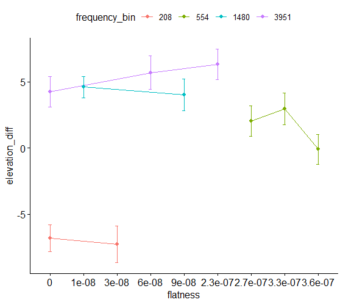

Interaction Plot

```r
#Last but not least:
interaction.plot_complex.flatness <-
  ggline(data_group1_complex, x = "flatness", y = "elevation_diff", color = "frequency_bin",
       add = c("mean_se"))
```

### 1.3 Spectral Roll-Off (Complex):

```r
#Were working with the complex-tones dataset first:
data_group1_complex$frequency_bin <- as.factor(data_group1_complex$frequency_bin)

#Lets check for interaction first:
ancova.complex.ele_freq_roll_off <- lm(elevation_diff~frequency_bin+roll_off, data=data_group1_complex)

vif(ancova.complex.ele_freq_roll_off)
```

```
##                   GVIF Df GVIF^(1/(2*Df))
## frequency_bin 571.4765  3        2.880711
## roll_off      571.4765  1       23.905574
```

```r
#number >5 meaning we should add the interaction term

ancova.complex.ele_freqXroll_off <- lm(elevation_diff~frequency_bin*roll_off, data=data_group1_complex)
```

More Stats:

```r
#ANOVA for significance:
anova(ancova.complex.ele_freqXroll_off)
```

```
## Analysis of Variance Table
##
## Response: elevation_diff
##                          Df  Sum Sq Mean Sq F value Pr(>F)
## frequency_bin             3   72446 24148.6 61.8598 <2e-16 ***
## roll_off                  1     202   202.0  0.5174 0.4720
## frequency_bin:roll_off    3    1369   456.3  1.1688 0.3201
## Residuals              3052 1191427   390.4
## ---
## Signif. codes:  0 '***' 0.001 '**' 0.01 '*' 0.05 '.' 0.1 ' ' 1
```

```r
#Post-Hoc:
emtrends(ancova.complex.ele_freqXroll_off,
         pairwise~frequency_bin, var="roll_off")
```

```
## $emtrends
##  frequency_bin roll_off.trend      SE   df lower.CL upper.CL
##  208                  0.04543 0.07290 3052 -0.09752   0.1884
##  554                  0.04764 0.02730 3052 -0.00596   0.1012
##  1480                 0.00764 0.01020 3052 -0.01242   0.0277
##  3951                -0.00159 0.00781 3052 -0.01690   0.0137
##
## Confidence level used: 0.95
##
## $contrasts
##  contrast                              estimate     SE   df t.ratio p.value
##  frequency_bin208 - frequency_bin554   -0.00221 0.0779 3052  -0.028  1.0000
##  frequency_bin208 - frequency_bin1480   0.03780 0.0736 3052   0.513  0.9559
##  frequency_bin208 - frequency_bin3951   0.04702 0.0733 3052   0.641  0.9186
##  frequency_bin554 - frequency_bin1480   0.04000 0.0292 3052   1.370  0.5180
##  frequency_bin554 - frequency_bin3951   0.04923 0.0284 3052   1.731  0.3074
##  frequency_bin1480 - frequency_bin3951  0.00922 0.0129 3052   0.717  0.8905
##
## P value adjustment: tukey method for comparing a family of 4 estimates
```

#### Results

Anova-table: In conclusion, again the Pratts Effect is given (p<2e-16 ***). However, there was no prediction of elevation differences by roll_off values and roll_off also does not interact with frequency_bin.

Emtrends and Emmeans-table: Slope-Situation (roll_off.trend) looks just like the one for centroid, we would have, if significance was a thing (sadly its not) a positive relation between elevation differences and roll-off for the first three frequency bins, but not for the last on, containing the highest tones. Here, the slope was negative again.

And interaction-plot:

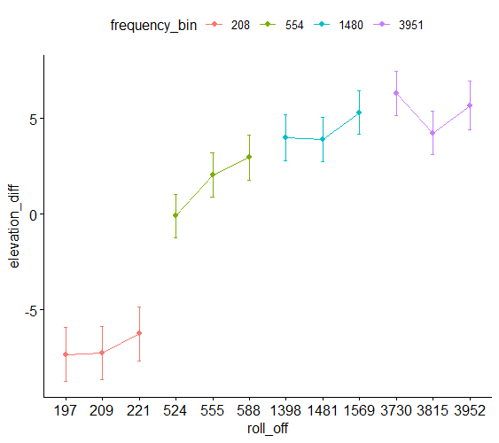

Interaction Plot

```r
#visualization:
interaction.plot_complex.roll_off <-
  ggline(data_group1_complex, x = "roll_off", y = "elevation_diff", color = "frequency_bin",
       add = c("mean_se"))
```

This one looks similar to the one for centroid. Which would also be explained by our lovely statistics again!